# 3: NHANES Data Analysis

15/06/2020

## 0: Data Preparation

Load relevant packages:

```r
library(nhanesA)
library(skimr)
library(mstate)
library(cmprsk)
library(gridExtra)
library(finalfit)
library(tidyverse)
library(ggplot2)
```

In this data analysis, the NHANES 2005-2006 data was used [1], as well as the 2015 Linked Mortality File (LMF) [2] which is contained in the file `outcome.csv’.

## Import NHANES tables

To import the NHANES 2005-2006 tables, a tutorial by C.Endres was followed [3].

Import age and gender from demographic table.

```r
demo_d  <- nhanes('DEMO_D') %>% select('SEQN', 'RIDAGEYR', 'RIAGENDR') %>% mutate(RIAGENDR = factor(RIAGENDR))
```

```
## Processing SAS dataset DEMO_D     ..
```

No missing data, 1= male, 2 = female, age between 0 and 85 (all above 84 given 85)

Load body measurement data

```r
bmx_d  <- nhanes('BMX_D') %>% select('SEQN', 'BMXBMI')
```

```
## Processing SAS dataset BMX_D      ..
```

```r
data0 <- merge(demo_d, bmx_d, by = 'SEQN')
```

About 10% BMI data is missing.

Load blood pressure measurements :

Systolic blood pressure mmHg 1st reading

```r
systolic  <- nhanes('BPX_D') %>% select('SEQN', 'BPXSY1')
```

```
## Processing SAS dataset BPX_D      ..
```

Lab measurements for cholesterol levels:

```r
ldl <- nhanes('TRIGLY_D') %>% select('SEQN', 'LBDLDL')
```

```
## Processing SAS dataset TRIGLY_D   ..
```

```r
data1 <- merge(data0, ldl, by = 'SEQN')
```

Load questionnare diabetes data:

```r
# Ever told by doctor you have diabetes?
diq_d <- nhanes('DIQ_D') %>% select('SEQN', 'DIQ010') %>% mutate(DIQ010 = factor(DIQ010))
```

```
## Processing SAS dataset DIQ_D      ..
```

```r
diabetes_d <- nhanesTranslate('DIQ_D', 'DIQ010', data=diq_d)
```

```
## Translated columns: DIQ010
```

```r
data2 <- merge(data1, diabetes_d, by = 'SEQN')




# Cigarette use questionnaire data
# Smoked at least 100 cigarettes in life?

smq_d <- nhanes('SMQ_D') %>% select('SEQN', 'SMQ020') %>% mutate(SMQ020 = factor(SMQ020))
```

```
## Processing SAS dataset SMQ_D      ..
```

```r
smoke_d <- nhanesTranslate('SMQ_D', 'SMQ020', data=smq_d)
```

```
## Translated columns: SMQ020
```

```r
data3 <- merge(data2, smoke_d)

data4 <- merge(data3, systolic)

covariates <- nhanesTranslate('DEMO_D', 'RIAGENDR', data=data4)
```

```
## Translated columns: RIAGENDR
```

```r
summary(covariates)
```

```
##       SEQN          RIDAGEYR      RIAGENDR        BMXBMI           LBDLDL
##  Min.   :31130   Min.   :12.0   Male  :1658   Min.   : 13.43   Min.   : 19.0
##  1st Qu.:33730   1st Qu.:18.0   Female:1694   1st Qu.: 22.23   1st Qu.: 81.0
##  Median :36354   Median :33.0                 Median : 26.27   Median :103.0
##  Mean   :36331   Mean   :37.8                 Mean   : 27.37   Mean   :106.8
##  3rd Qu.:38900   3rd Qu.:54.0                 3rd Qu.: 30.95   3rd Qu.:130.0
##  Max.   :41474   Max.   :85.0                 Max.   :130.21   Max.   :328.0
##                                               NA's   :50       NA's   :326
##         DIQ010            SMQ020         BPXSY1
##  Yes       : 245   Yes       :1114   Min.   : 74.0
##  No        :3063   No        :1172   1st Qu.:108.0
##  Borderline:  41   Refused   :   0   Median :116.0
##  Don't know:   3   Don't know:   3   Mean   :120.2
##                    NA's      :1063   3rd Qu.:128.0
##                                      Max.   :224.0
##                                      NA's   :448
```

```r
skim(covariates)
```

Data summary

| Name | covariates |
| --- | --- |
| Number of rows | 3352 |
| Number of columns | 8 |
| _______________________ |  |
| Column type frequency: |  |
| character | 4 |
| factor | 3 |
| numeric | 1 |
| ________________________ |  |
| Group variables | None |

**Variable type: character**

| skim_variable | n_missing | complete_rate | min | max | empty | n_unique | whitespace |
| --- | --- | --- | --- | --- | --- | --- | --- |
| SEQN | 0 | 1.00 | 5 | 5 | 0 | 3352 | 0 |
| RIDAGEYR | 0 | 1.00 | 2 | 2 | 0 | 74 | 0 |
| LBDLDL | 326 | 0.90 | 2 | 3 | 0 | 196 | 0 |
| BPXSY1 | 448 | 0.87 | 2 | 3 | 0 | 69 | 0 |

**Variable type: factor**

| skim_variable | n_missing | complete_rate | ordered | n_unique | top_counts |
| --- | --- | --- | --- | --- | --- |
| RIAGENDR | 0 | 1.00 | FALSE | 2 | Fem: 1694, Mal: 1658 |
| DIQ010 | 0 | 1.00 | FALSE | 4 | No: 3063, Yes: 245, Bor: 41, Don: 3 |
| SMQ020 | 1063 | 0.68 | FALSE | 3 | No: 1172, Yes: 1114, Don: 3, Ref: 0 |

**Variable type: numeric**

| skim_variable | n_missing | complete_rate | mean | sd | p0 | p25 | p50 | p75 | p100 | hist |
| --- | --- | --- | --- | --- | --- | --- | --- | --- | --- | --- |
| BMXBMI | 50 | 0.99 | 27.37 | 7.28 | 13.43 | 22.225 | 26.265 | 30.9475 | 130.21 | ▇▁▁▁▁ |

## Load mortality data

```r
outcome = read_csv('outcome.csv') %>% select(-'X1')
# Convert data types
data <- merge(covariates, outcome, by = 'SEQN') %>% mutate(SEQN = factor(SEQN)) %>%
  mutate(eligstat = factor(eligstat),
         mortstat = factor(mortstat),
         ucod_leading = factor(ucod_leading),
         permth_int = as.numeric(permth_int),
         permth_exm = as.numeric(permth_exm),
         RIDAGEYR = as.numeric(RIDAGEYR),
         RIAGENDR = factor(RIAGENDR),
         BMXBMI = as.numeric(BMXBMI),
         LBDLDL = as.numeric(LBDLDL),
         DIQ010 = factor(DIQ010),
         BPXSY1 = as.numeric(BPXSY1),
         SMQ020 = factor(SMQ020))

summary(data)
```

```
##       SEQN         RIDAGEYR      RIAGENDR        BMXBMI           LBDLDL
##  31130  :   1   Min.   :12.0   Male  :1658   Min.   : 13.43   Min.   : 19.0
##  31131  :   1   1st Qu.:18.0   Female:1694   1st Qu.: 22.23   1st Qu.: 81.0
##  31132  :   1   Median :33.0                 Median : 26.27   Median :103.0
##  31133  :   1   Mean   :37.8                 Mean   : 27.37   Mean   :106.8
##  31134  :   1   3rd Qu.:54.0                 3rd Qu.: 30.95   3rd Qu.:130.0
##  31139  :   1   Max.   :85.0                 Max.   :130.21   Max.   :328.0
##  (Other):3346                                NA's   :50       NA's   :326
##         DIQ010            SMQ020         BPXSY1      eligstat mortstat
##  Yes       : 245   Yes       :1114   Min.   : 74.0   1:2565   0   :2230
##  No        :3063   No        :1172   1st Qu.:108.0   2: 785   1   : 335
##  Borderline:  41   Don't know:   3   Median :116.0   3:   2   NA's: 787
##  Don't know:   3   NA's      :1063   Mean   :120.2
##                                      3rd Qu.:128.0
##                                      Max.   :224.0
##                                      NA's   :448
##   ucod_leading    permth_int      permth_exm
##  10     : 134   Min.   :  2.0   Min.   :  1.0
##  1      :  63   1st Qu.:112.0   1st Qu.:112.0
##  2      :  62   Median :119.0   Median :118.0
##  3      :  18   Mean   :113.2   Mean   :112.4
##  5      :  15   3rd Qu.:127.0   3rd Qu.:126.0
##  (Other):  43   Max.   :132.0   Max.   :132.0
##  NA's   :3017   NA's   :787     NA's   :787
```

```r
skim(data)
```

Data summary

| Name | data |
| --- | --- |
| Number of rows | 3352 |
| Number of columns | 13 |
| _______________________ |  |
| Column type frequency: |  |
| factor | 7 |
| numeric | 6 |
| ________________________ |  |
| Group variables | None |

**Variable type: factor**

| skim_variable | n_missing | complete_rate | ordered | n_unique | top_counts |
| --- | --- | --- | --- | --- | --- |
| SEQN | 0 | 1.00 | FALSE | 3352 | 311: 1, 311: 1, 311: 1, 311: 1 |
| RIAGENDR | 0 | 1.00 | FALSE | 2 | Fem: 1694, Mal: 1658 |
| DIQ010 | 0 | 1.00 | FALSE | 4 | No: 3063, Yes: 245, Bor: 41, Don: 3 |
| SMQ020 | 1063 | 0.68 | FALSE | 3 | No: 1172, Yes: 1114, Don: 3 |
| eligstat | 0 | 1.00 | FALSE | 3 | 1: 2565, 2: 785, 3: 2 |
| mortstat | 787 | 0.77 | FALSE | 2 | 0: 2230, 1: 335 |
| ucod_leading | 3017 | 0.10 | FALSE | 10 | 10: 134, 1: 63, 2: 62, 3: 18 |

**Variable type: numeric**

| skim_variable | n_missing | complete_rate | mean | sd | p0 | p25 | p50 | p75 | p100 | hist |
| --- | --- | --- | --- | --- | --- | --- | --- | --- | --- | --- |
| RIDAGEYR | 0 | 1.00 | 37.80 | 21.84 | 12.00 | 18.00 | 33.00 | 54.00 | 85.00 | ▇▃▃▂▂ |
| BMXBMI | 50 | 0.99 | 27.37 | 7.28 | 13.43 | 22.22 | 26.27 | 30.95 | 130.21 | ▇▁▁▁▁ |
| LBDLDL | 326 | 0.90 | 106.78 | 35.83 | 19.00 | 81.00 | 103.00 | 130.00 | 328.00 | ▃▇▂▁▁ |
| BPXSY1 | 448 | 0.87 | 120.22 | 18.69 | 74.00 | 108.00 | 116.00 | 128.00 | 224.00 | ▂▇▂▁▁ |
| permth_int | 787 | 0.77 | 113.19 | 24.33 | 2.00 | 112.00 | 119.00 | 127.00 | 132.00 | ▁▁▁▁▇ |
| permth_exm | 787 | 0.77 | 112.38 | 24.36 | 1.00 | 112.00 | 118.00 | 126.00 | 132.00 | ▁▁▁▁▇ |

## Data checks and exploration

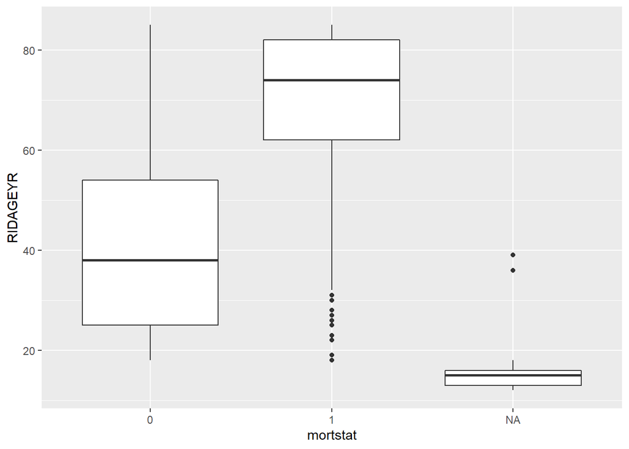

```r
ggplot(data, aes(x = mortstat, y = RIDAGEYR)) + geom_boxplot()
```

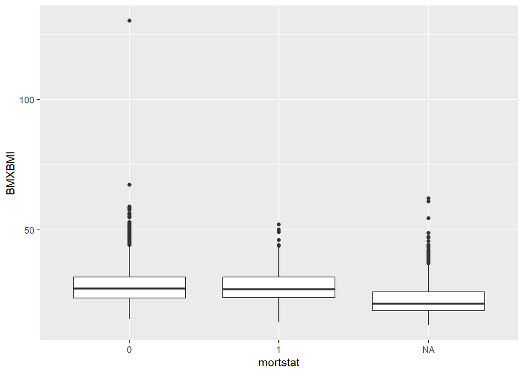

```r
ggplot(data, aes(x = mortstat, y = BMXBMI)) + geom_boxplot()
```

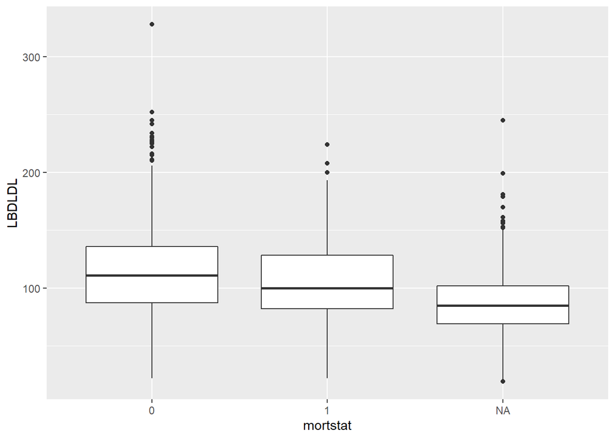

```r
ggplot(data, aes(x = mortstat, y = LBDLDL)) + geom_boxplot()
```

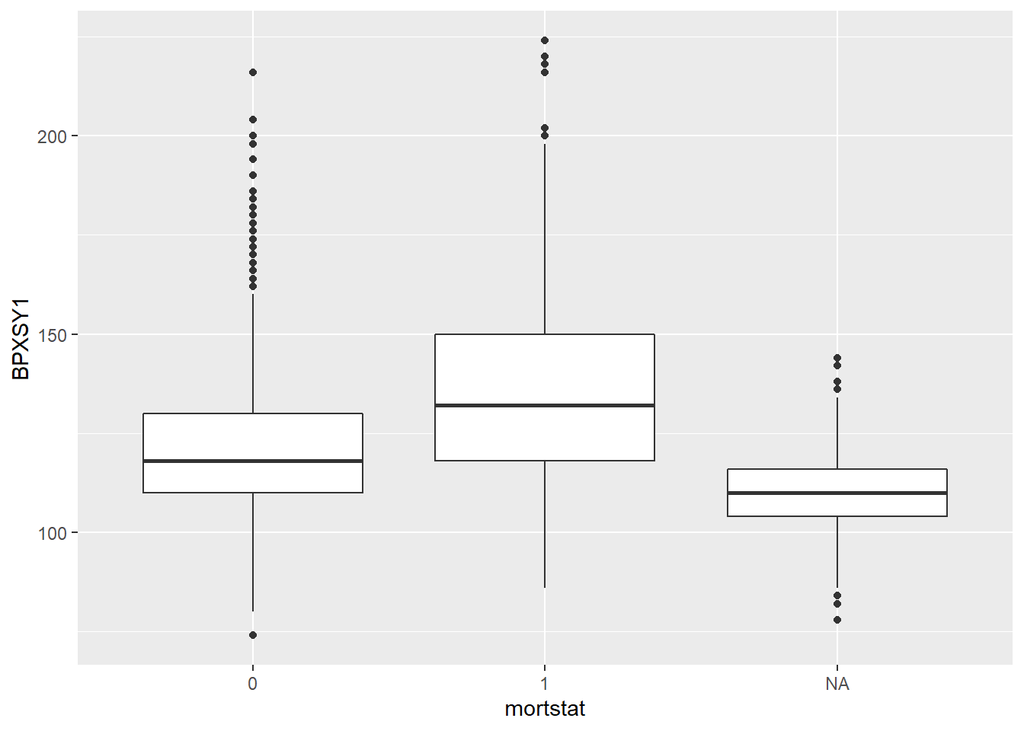

```r
ggplot(data, aes(x = mortstat, y = BPXSY1)) + geom_boxplot()
```

### Change data format

Change format of ucod_leading so that :

- 0 = Ineligible, under age 18, assumed alive, or no cause of death data
- 1 = death from disease of the heart
- 2 = maligant neoplasms (cancer)
- 3 = all other causes e.g. accidents, respiratory, diabetes etc.

```r
# First convert 0s to NA's
summary(data$ucod_leading)
```

```
##    1    2    3    4    5    6    7    8    9   10 NA's
##   63   62   18   10   15    8    9    6   10  134 3017
```

```r
levels(data$ucod_leading)
```

```
##  [1] "1"  "2"  "3"  "4"  "5"  "6"  "7"  "8"  "9"  "10"
```

```r
levels(data$ucod_leading) <- c(levels(data$ucod_leading),"0")

data$ucod_leading[is.na(data$ucod_leading)] <- 0
summary(data$ucod_leading)
```

```
##    1    2    3    4    5    6    7    8    9   10    0
##   63   62   18   10   15    8    9    6   10  134 3017
```

```r
# Convert 3-10 to 3
cause <- data.frame(ucod_leading=c(0, 1, 2, 3, 4, 5, 6, 7, 8, 9, 10), cause =c(0, 1, 2, 3, 3, 3, 3, 3, 3, 3, 3))
df2 <- merge(data,cause, by = 'ucod_leading') %>%
  mutate(SEQN = factor(SEQN),
         eligstat = factor(eligstat),
         mortstat = factor(mortstat),
         ucod_leading = factor(ucod_leading),
         permth_int = as.numeric(permth_int),
         permth_exm = as.numeric(permth_exm),
         RIDAGEYR = as.numeric(RIDAGEYR)/10,
         RIAGENDR = factor(RIAGENDR),
         BMXBMI = as.numeric(BMXBMI),
         LBDLDL = as.numeric(LBDLDL)/10,
         DIQ010 = factor(DIQ010),
         BPXSY1 = as.numeric(BPXSY1)/10,
         SMQ020 = factor(SMQ020),
         cause = factor(cause))


summary(df2)
```

```
##   ucod_leading       SEQN         RIDAGEYR      RIAGENDR        BMXBMI
##  0      :3017   31130  :   1   Min.   :1.20   Male  :1658   Min.   : 13.43
##  10     : 134   31131  :   1   1st Qu.:1.80   Female:1694   1st Qu.: 22.23
##  1      :  63   31132  :   1   Median :3.30                 Median : 26.27
##  2      :  62   31133  :   1   Mean   :3.78                 Mean   : 27.37
##  3      :  18   31134  :   1   3rd Qu.:5.40                 3rd Qu.: 30.95
##  5      :  15   31139  :   1   Max.   :8.50                 Max.   :130.21
##  (Other):  43   (Other):3346                                NA's   :50
##      LBDLDL             DIQ010            SMQ020         BPXSY1      eligstat
##  Min.   : 1.90   Yes       : 245   Yes       :1114   Min.   : 7.40   1:2565
##  1st Qu.: 8.10   No        :3063   No        :1172   1st Qu.:10.80   2: 785
##  Median :10.30   Borderline:  41   Don't know:   3   Median :11.60   3:   2
##  Mean   :10.68   Don't know:   3   NA's      :1063   Mean   :12.02
##  3rd Qu.:13.00                                       3rd Qu.:12.80
##  Max.   :32.80                                       Max.   :22.40
##  NA's   :326                                         NA's   :448
##  mortstat      permth_int      permth_exm    cause
##  0   :2230   Min.   :  2.0   Min.   :  1.0   0:3017
##  1   : 335   1st Qu.:112.0   1st Qu.:112.0   1:  63
##  NA's: 787   Median :119.0   Median :118.0   2:  62
##              Mean   :113.2   Mean   :112.4   3: 210
##              3rd Qu.:127.0   3rd Qu.:126.0
##              Max.   :132.0   Max.   :132.0
##              NA's   :787     NA's   :787
```

## Data in long format for mstate

Convert data into long format with K rows per individual

```r
head(df2)
```

```
##   ucod_leading  SEQN RIDAGEYR RIAGENDR BMXBMI LBDLDL DIQ010 SMQ020 BPXSY1
## 1            0 31133      1.6   Female  16.79    8.1     No   <NA>   12.0
## 2            0 31134      7.3     Male  30.63    9.8     No     No   13.0
## 3            0 31155      3.8     Male  25.61    9.1     No     No   12.6
## 4            0 31158      7.1     Male  21.65   11.0     No    Yes   15.4
## 5            0 31139      1.8   Female  29.45     NA     No   <NA>   11.0
## 6            0 31132      7.0     Male  24.74    7.5    Yes     No   13.8
##   eligstat mortstat permth_int permth_exm cause
## 1        2     <NA>         NA         NA     0
## 2        1        0        124        123     0
## 3        1        0        124        123     0
## 4        1        0        120        119     0
## 5        1        0        122        122     0
## 6        1        0        129        129     0
```

```r
data_short <- df2 %>%
  select(-c(permth_int, mortstat, eligstat, ucod_leading)) %>%
  rename(time = permth_exm, status = cause)


causes <- data.frame(status=c(0, 1, 2, 3), cause = c("event-free", "heart", "cancer", "other"))

data_short <- merge(data_short, causes, by = "status")
head(data_short)
```

```
##   status  SEQN RIDAGEYR RIAGENDR BMXBMI LBDLDL DIQ010 SMQ020 BPXSY1 time
## 1      0 31133      1.6   Female  16.79    8.1     No   <NA>   12.0   NA
## 2      0 31134      7.3     Male  30.63    9.8     No     No   13.0  123
## 3      0 31155      3.8     Male  25.61    9.1     No     No   12.6  123
## 4      0 31158      7.1     Male  21.65   11.0     No    Yes   15.4  119
## 5      0 31139      1.8   Female  29.45     NA     No   <NA>   11.0  122
## 6      0 31132      7.0     Male  24.74    7.5    Yes     No   13.8  129
##        cause
## 1 event-free
## 2 event-free
## 3 event-free
## 4 event-free
## 5 event-free
## 6 event-free
```

```r
# Individuals with missing time are inelidgible or under 18
summary(data_short$time)
```

```
##    Min. 1st Qu.  Median    Mean 3rd Qu.    Max.    NA's
##     1.0   112.0   118.0   112.4   126.0   132.0     787
```

```r
# Remove ineligible individuals
data_short <- data_short[!is.na(data_short$time), ]

# Remove individuals with missing covariates
data_short <- na.omit(data_short)

# Remove individuals in 'Don't know' categories
data_short <- data_short %>%
  filter(!(DIQ010 == "Don't know" | SMQ020 == "Don't know"))


data_short$DIQ010 <- droplevels(data_short$DIQ010, exclude = "Don't know")
data_short$SMQ020 <- droplevels(data_short$SMQ020, exclude = "Don't know")


# Reorder
data_short <- data_short %>% select(SEQN, time, status, cause, RIAGENDR, RIDAGEYR, BMXBMI, LBDLDL, DIQ010, BPXSY1, SMQ020) %>% mutate(SEQN = as.integer(SEQN))

#Order factor levels to make output easier to read
data_short$DIQ010 = factor(data_short$DIQ010 ,
                    levels=c("No", "Borderline", "Yes"))

data_short$SMQ020 = factor(data_short$SMQ020 ,
                    levels=c("No", "Yes"))


summary(data_short)
```

```
##       SEQN           time       status          cause        RIAGENDR
##  Min.   :   2   Min.   :  1.0   0:1568   cancer    :  46   Male  :884
##  1st Qu.: 886   1st Qu.:112.0   1:  49   event-free:1568   Female:925
##  Median :1697   Median :119.0   2:  46   heart     :  49
##  Mean   :1697   Mean   :112.8   3: 146   other     : 146
##  3rd Qu.:2528   3rd Qu.:126.0
##  Max.   :3351   Max.   :132.0
##     RIDAGEYR         BMXBMI           LBDLDL             DIQ010
##  Min.   :2.000   Min.   : 15.68   Min.   : 2.20   No        :1611
##  1st Qu.:3.200   1st Qu.: 24.20   1st Qu.: 8.80   Borderline:  30
##  Median :4.600   Median : 27.64   Median :11.30   Yes       : 168
##  Mean   :4.795   Mean   : 28.76   Mean   :11.49
##  3rd Qu.:6.300   3rd Qu.: 31.89   3rd Qu.:13.80
##  Max.   :8.500   Max.   :130.21   Max.   :32.80
##      BPXSY1      SMQ020
##  Min.   : 8.00   No :923
##  1st Qu.:11.20   Yes:886
##  Median :12.00
##  Mean   :12.41
##  3rd Qu.:13.40
##  Max.   :22.40
```

```r
skim(data_short)
```

Data summary

| Name | data_short |
| --- | --- |
| Number of rows | 1809 |
| Number of columns | 11 |
| _______________________ |  |
| Column type frequency: |  |
| factor | 5 |
| numeric | 6 |
| ________________________ |  |
| Group variables | None |

**Variable type: factor**

| skim_variable | n_missing | complete_rate | ordered | n_unique | top_counts |
| --- | --- | --- | --- | --- | --- |
| status | 0 | 1 | FALSE | 4 | 0: 1568, 3: 146, 1: 49, 2: 46 |
| cause | 0 | 1 | FALSE | 4 | eve: 1568, oth: 146, hea: 49, can: 46 |
| RIAGENDR | 0 | 1 | FALSE | 2 | Fem: 925, Mal: 884 |
| DIQ010 | 0 | 1 | FALSE | 3 | No: 1611, Yes: 168, Bor: 30 |
| SMQ020 | 0 | 1 | FALSE | 2 | No: 923, Yes: 886 |

**Variable type: numeric**

| skim_variable | n_missing | complete_rate | mean | sd | p0 | p25 | p50 | p75 | p100 | hist |
| --- | --- | --- | --- | --- | --- | --- | --- | --- | --- | --- |
| SEQN | 0 | 1 | 1697.48 | 961.02 | 2.00 | 886.0 | 1697.00 | 2528.00 | 3351.00 | ▇▇▇▇▇ |
| time | 0 | 1 | 112.80 | 24.05 | 1.00 | 112.0 | 119.00 | 126.00 | 132.00 | ▁▁▁▁▇ |
| RIDAGEYR | 0 | 1 | 4.79 | 1.88 | 2.00 | 3.2 | 4.60 | 6.30 | 8.50 | ▇▆▅▅▃ |
| BMXBMI | 0 | 1 | 28.76 | 7.02 | 15.68 | 24.2 | 27.64 | 31.89 | 130.21 | ▇▁▁▁▁ |
| LBDLDL | 0 | 1 | 11.49 | 3.68 | 2.20 | 8.8 | 11.30 | 13.80 | 32.80 | ▃▇▂▁▁ |
| BPXSY1 | 0 | 1 | 12.41 | 1.98 | 8.00 | 11.2 | 12.00 | 13.40 | 22.40 | ▃▇▂▁▁ |

```r
# Check correlation between covariates:

round(cor(data_short %>% select(-c(time, SEQN, DIQ010, SMQ020, RIAGENDR, cause, status))), 2)
```

```
##          RIDAGEYR BMXBMI LBDLDL BPXSY1
## RIDAGEYR     1.00   0.03   0.04   0.48
## BMXBMI       0.03   1.00   0.02   0.15
## LBDLDL       0.04   0.02   1.00   0.03
## BPXSY1       0.48   0.15   0.03   1.00
```

Systolic blood pressure appears to be positively correlated with BMI, and age.

The code below estimating the Cox model regression coefficients and the cumulative incidence for a given covariate using the `mstate` package has been adapted from a tutorial by H.Putter [4].

```r
# Number of each event:
table(data_short$status)
```

```
##
##    0    1    2    3
## 1568   49   46  146
```

```r
# Competing risk transition matrix
tmat <- trans.comprisk(3, names = c("event-free", "heart", "cancer", "other"))
tmat
```

```
##             to
## from         event-free heart cancer other
##   event-free         NA     1      2     3
##   heart              NA    NA     NA    NA
##   cancer             NA    NA     NA    NA
##   other              NA    NA     NA    NA
```

```r
# Can only go from event free to one of the K=3 causes
```

```r
# Indicator columns for each of the 3 causes of deaths
data_short$stat1 <- as.numeric(data_short$status == 1)
data_short$stat2 <- as.numeric(data_short$status == 2)
data_short$stat3 <- as.numeric(data_short$status == 3)

head(data_short)
```

```
##   SEQN time status      cause RIAGENDR RIDAGEYR BMXBMI LBDLDL DIQ010 BPXSY1
## 1    5  123      0 event-free     Male      7.3  30.63    9.8     No   13.0
## 2   12  123      0 event-free     Male      3.8  25.61    9.1     No   12.6
## 3   13  119      0 event-free     Male      7.1  21.65   11.0     No   15.4
## 4    3  129      0 event-free     Male      7.0  24.74    7.5    Yes   13.8
## 5   18  126      0 event-free   Female      3.3  25.70    8.6     No   11.4
## 6   20  129      0 event-free   Female      2.2  25.26   11.2     No   10.8
##   SMQ020 stat1 stat2 stat3
## 1     No     0     0     0
## 2     No     0     0     0
## 3    Yes     0     0     0
## 4     No     0     0     0
## 5     No     0     0     0
## 6     No     0     0     0
```

```r
# Convert data into long format using msprep:
data_long <- msprep(time = c(NA, "time", "time", "time"), status = c(NA, "stat1", "stat2", "stat3"), data = data_short, keep = c("RIDAGEYR", "RIAGENDR", "BMXBMI", "LBDLDL", "DIQ010", "BPXSY1", "SMQ020"), trans = tmat)

tail(data_long)
```

```
## An object of class 'msdata'
##
## Data:
##        id from to trans Tstart Tstop time status RIDAGEYR RIAGENDR BMXBMI
## 5422 1808    1  2     1      0    58   58      0      7.8   Female  33.42
## 5423 1808    1  3     2      0    58   58      0      7.8   Female  33.42
## 5424 1808    1  4     3      0    58   58      1      7.8   Female  33.42
## 5425 1809    1  2     1      0    93   93      0      7.7   Female  33.26
## 5426 1809    1  3     2      0    93   93      0      7.7   Female  33.26
## 5427 1809    1  4     3      0    93   93      1      7.7   Female  33.26
##      LBDLDL DIQ010 BPXSY1 SMQ020
## 5422   11.4    Yes   11.2    Yes
## 5423   11.4    Yes   11.2    Yes
## 5424   11.4    Yes   11.2    Yes
## 5425    4.0    Yes   15.8     No
## 5426    4.0    Yes   15.8     No
## 5427    4.0    Yes   15.8     No
```

```r
# Check number of events same as before:
events(data_long)
```

```
## $Frequencies
##             to
## from         event-free heart cancer other no event total entering
##   event-free          0    49     46   146     1568           1809
##   heart               0     0      0     0       49             49
##   cancer              0     0      0     0       46             46
##   other               0     0      0     0      146            146
##
## $Proportions
##             to
## from         event-free      heart     cancer      other   no event
##   event-free 0.00000000 0.02708679 0.02542841 0.08070757 0.86677722
##   heart      0.00000000 0.00000000 0.00000000 0.00000000 1.00000000
##   cancer     0.00000000 0.00000000 0.00000000 0.00000000 1.00000000
##   other      0.00000000 0.00000000 0.00000000 0.00000000 1.00000000
```

```r
# Add cause-specific covariates for regression:
data_long <- expand.covs(data_long, covs = c("RIDAGEYR","RIAGENDR","BMXBMI","LBDLDL", "DIQ010", "BPXSY1", "SMQ020"))

head(data_long)
```

```
## An object of class 'msdata'
##
## Data:
##   id from to trans Tstart Tstop time status RIDAGEYR RIAGENDR BMXBMI LBDLDL
## 1  1    1  2     1      0   123  123      0      7.3     Male  30.63    9.8
## 2  1    1  3     2      0   123  123      0      7.3     Male  30.63    9.8
## 3  1    1  4     3      0   123  123      0      7.3     Male  30.63    9.8
## 4  2    1  2     1      0   123  123      0      3.8     Male  25.61    9.1
## 5  2    1  3     2      0   123  123      0      3.8     Male  25.61    9.1
## 6  2    1  4     3      0   123  123      0      3.8     Male  25.61    9.1
##   DIQ010 BPXSY1 SMQ020 RIDAGEYR.1 RIDAGEYR.2 RIDAGEYR.3 RIAGENDRFemale.1
## 1     No   13.0     No        7.3        0.0        0.0                0
## 2     No   13.0     No        0.0        7.3        0.0                0
## 3     No   13.0     No        0.0        0.0        7.3                0
## 4     No   12.6     No        3.8        0.0        0.0                0
```

[output cut: 30 more lines]

# Non-parametric estimators for cumulative incidence

## Aalen-Johanssen Estimator

```r
ci <- Cuminc(time = "time", status = "status", data = data_short)

head(ci)
```

```
##   time      Surv         CI.1         CI.2         CI.3       seSurv
## 1    1 0.9994472 0.0000000000 0.0000000000 0.0005527916 0.0005526388
## 2    2 0.9983416 0.0005527916 0.0005527916 0.0005527916 0.0009566689
## 3    3 0.9966833 0.0005527916 0.0011055832 0.0016583748 0.0013518099
## 4    4 0.9961305 0.0005527916 0.0011055832 0.0022111664 0.0014597167
## 5    5 0.9955777 0.0005527916 0.0011055832 0.0027639580 0.0015600697
## 6    6 0.9950249 0.0005527916 0.0011055832 0.0033167496 0.0016542443
##         seCI.1       seCI.2       seCI.3
## 1 0.0000000000 0.0000000000 0.0005526388
## 2 0.0005526388 0.0005526388 0.0005526388
## 3 0.0005526388 0.0007813331 0.0009566689
## 4 0.0005526388 0.0007813331 0.0011043602
## 5 0.0005526388 0.0007813331 0.0012343702
## 6 0.0005526388 0.0007813331 0.0013518099
```

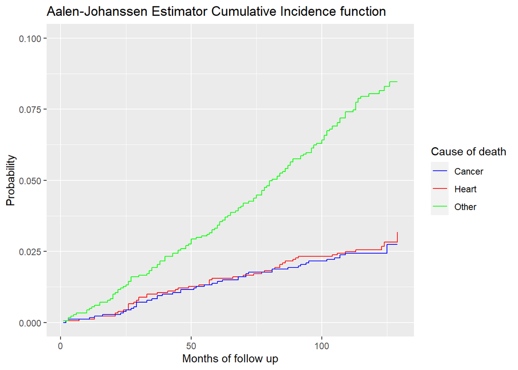

```r
# Plot
ggplot(ci) +
      geom_step(aes(x = time, y = CI.1, color = 'Heart')) +
      geom_step(aes(x = time, y = CI.2, color = 'Cancer')) +
  geom_step(aes(x = time, y = CI.3, color = 'Other')) +
  labs(title = 'Aalen-Johanssen Estimator Cumulative Incidence function') + xlab('Months of follow up') + ylab('Probability') + ylim(0,0.1) +
scale_colour_manual(name="Cause of death",
    values=c(Heart="red", Cancer="blue", Other = "green"))
```

# 1: Cox model

```r
# Stratified hazards model
c1 <- coxph(Surv(time, status) ~ RIDAGEYR.1 + RIDAGEYR.2 +  RIDAGEYR.3  + RIAGENDRFemale.1 + RIAGENDRFemale.2 + RIAGENDRFemale.3  + BMXBMI.1 + BMXBMI.2 + BMXBMI.3  + LBDLDL.1 + LBDLDL.2 + LBDLDL.3 + DIQ010Borderline.1 + DIQ010Borderline.2 + DIQ010Borderline.3 + DIQ010Yes.1 + DIQ010Yes.2 + DIQ010Yes.3 + BPXSY1.1 + BPXSY1.2 + BPXSY1.3 + SMQ020Yes.1 + SMQ020Yes.2 + SMQ020Yes.3 + strata(trans), data = data_long)


summary(c1)
```

```
## Call:
## coxph(formula = Surv(time, status) ~ RIDAGEYR.1 + RIDAGEYR.2 +
##     RIDAGEYR.3 + RIAGENDRFemale.1 + RIAGENDRFemale.2 + RIAGENDRFemale.3 +
##     BMXBMI.1 + BMXBMI.2 + BMXBMI.3 + LBDLDL.1 + LBDLDL.2 + LBDLDL.3 +
##     DIQ010Borderline.1 + DIQ010Borderline.2 + DIQ010Borderline.3 +
##     DIQ010Yes.1 + DIQ010Yes.2 + DIQ010Yes.3 + BPXSY1.1 + BPXSY1.2 +
##     BPXSY1.3 + SMQ020Yes.1 + SMQ020Yes.2 + SMQ020Yes.3 + strata(trans),
##     data = data_long)
##
##   n= 5427, number of events= 241
##
##                         coef exp(coef)  se(coef)      z Pr(>|z|)
## RIDAGEYR.1          0.725583  2.065935  0.116254  6.241 4.34e-10 ***
## RIDAGEYR.2          0.837456  2.310481  0.124960  6.702 2.06e-11 ***
## RIDAGEYR.3          0.825470  2.282955  0.068883 11.984  < 2e-16 ***
## RIAGENDRFemale.1   -0.723129  0.485231  0.325143 -2.224  0.02615 *
## RIAGENDRFemale.2   -0.585039  0.557084  0.325258 -1.799  0.07207 .
## RIAGENDRFemale.3   -0.016164  0.983966  0.173985 -0.093  0.92598
## BMXBMI.1           -0.015148  0.984966  0.027072 -0.560  0.57578
## BMXBMI.2            0.034787  1.035399  0.015870  2.192  0.02838 *
## BMXBMI.3           -0.016408  0.983726  0.015058 -1.090  0.27585
## LBDLDL.1           -0.016031  0.984097  0.041231 -0.389  0.69742
## LBDLDL.2           -0.065582  0.936522  0.044421 -1.476  0.13984
## LBDLDL.3           -0.063351  0.938614  0.024706 -2.564  0.01034 *
## DIQ010Borderline.1 -0.449747  0.637789  1.020466 -0.441  0.65941
## DIQ010Borderline.2  0.255683  1.291343  0.734145  0.348  0.72764
## DIQ010Borderline.3 -0.222766  0.800302  0.593135 -0.376  0.70723
## DIQ010Yes.1        -0.013510  0.986581  0.431107 -0.031  0.97500
## DIQ010Yes.2         0.289745  1.336087  0.388163  0.746  0.45539
## DIQ010Yes.3         0.617177  1.853687  0.206199  2.993  0.00276 **
## BPXSY1.1            0.158713  1.172001  0.064290  2.469  0.01356 *
## BPXSY1.2           -0.028800  0.971611  0.075208 -0.383  0.70177
## BPXSY1.3           -0.001786  0.998215  0.040503 -0.044  0.96482
## SMQ020Yes.1         0.239402  1.270490  0.309425  0.774  0.43911
## SMQ020Yes.2         0.586168  1.797088  0.334536  1.752  0.07974 .
## SMQ020Yes.3         0.321161  1.378727  0.177801  1.806  0.07087 .
## ---
## Signif. codes:  0 '***' 0.001 '**' 0.01 '*' 0.05 '.' 0.1 ' ' 1
##
##                    exp(coef) exp(-coef) lower .95 upper .95
```

[output cut: 14 more lines]

```
## DIQ010Borderline.3    0.8003     1.2495   0.25025    2.5594
## DIQ010Yes.1           0.9866     1.0136   0.42381    2.2966
## DIQ010Yes.2           1.3361     0.7485   0.62435    2.8592
## DIQ010Yes.3           1.8537     0.5395   1.23743    2.7769
## BPXSY1.1              1.1720     0.8532   1.03325    1.3294
## BPXSY1.2              0.9716     1.0292   0.83845    1.1259
## BPXSY1.3              0.9982     1.0018   0.92204    1.0807
## SMQ020Yes.1           1.2705     0.7871   0.69277    2.3300
## SMQ020Yes.2           1.7971     0.5565   0.93285    3.4620
## SMQ020Yes.3           1.3787     0.7253   0.97305    1.9535
##
## Concordance= 0.86  (se = 0.012 )
## Likelihood ratio test= 486.8  on 24 df,   p=<2e-16
## Wald test            = 336.1  on 24 df,   p=<2e-16
## Score (logrank) test = 500.7  on 24 df,   p=<2e-16
```

### Using just coxph()

```r
# Alternative method using just coxph()

coxph(Surv(time,status==1)~  RIDAGEYR + RIAGENDR + BMXBMI + LBDLDL + DIQ010 + BPXSY1 + SMQ020, data = data_short)
```

```
## Call:
## coxph(formula = Surv(time, status == 1) ~ RIDAGEYR + RIAGENDR +
##     BMXBMI + LBDLDL + DIQ010 + BPXSY1 + SMQ020, data = data_short)
##
##                      coef exp(coef) se(coef)      z        p
## RIDAGEYR          0.72558   2.06594  0.11625  6.241 4.34e-10
## RIAGENDRFemale   -0.72313   0.48523  0.32514 -2.224   0.0261
## BMXBMI           -0.01515   0.98497  0.02707 -0.560   0.5758
## LBDLDL           -0.01603   0.98410  0.04123 -0.389   0.6974
## DIQ010Borderline -0.44975   0.63779  1.02047 -0.441   0.6594
## DIQ010Yes        -0.01351   0.98658  0.43111 -0.031   0.9750
## BPXSY1            0.15871   1.17200  0.06429  2.469   0.0136
## SMQ020Yes         0.23940   1.27049  0.30942  0.774   0.4391
##
## Likelihood ratio test=99.89  on 8 df, p=< 2.2e-16
## n= 1809, number of events= 49
```

```r
# Gives same results
```

### Get predicted Cumulative incidence using mstate package

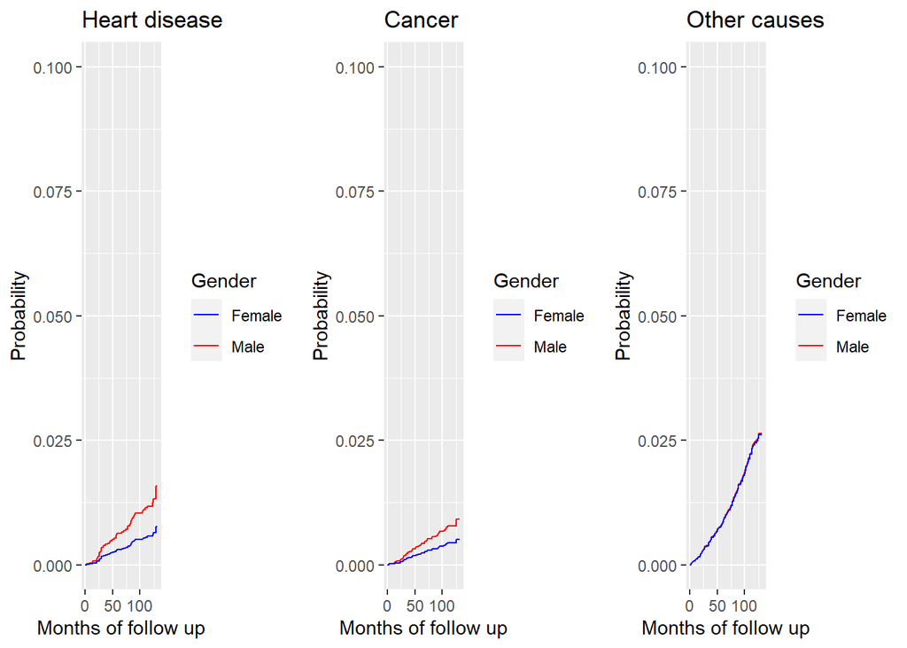

```r
par(mfrow = c(1, 3))

c1 <- coxph(Surv(time, status) ~ RIDAGEYR.1 + RIDAGEYR.2 +  RIDAGEYR.3  + RIAGENDRFemale.1 + RIAGENDRFemale.2 + RIAGENDRFemale.3  + BMXBMI.1 + BMXBMI.2 + BMXBMI.3  + LBDLDL.1 + LBDLDL.2 + LBDLDL.3 + DIQ010Borderline.1 + DIQ010Borderline.2 + DIQ010Borderline.3 + DIQ010Yes.1 + DIQ010Yes.2 + DIQ010Yes.3 + BPXSY1.1 + BPXSY1.2 + BPXSY1.3 + SMQ020Yes.1 + SMQ020Yes.2 + SMQ020Yes.3 + strata(trans), data = data_long, method = 'breslow')


# New data for individual with average covariate values and factors

# Compare incidence of each outcome for males and females, both BMI 28.8, LDL 115md/dL, aged 48, systolic blood pressure 124mmHg, with no diabetes and not smoked more than 100 cigarettes in lifetime
Male <- data.frame(RIDAGEYR.1 = c(4.8,0,0), RIDAGEYR.2 = c(0,4.8,0), RIDAGEYR.3 = c(0,0,4.8), RIAGENDRFemale.1 = c(0,0,0), RIAGENDRFemale.2 = c(0,0,0), RIAGENDRFemale.3 = c(0,0,0), BMXBMI.1 = c(28.8, 0,0 ), BMXBMI.2 = c( 0,28.8,0 ), BMXBMI.3 = c( 0,0,28.8), LBDLDL.1 = c(11.5,0 ,0 ), LBDLDL.2 = c( 0,11.5,0 ), LBDLDL.3 = c( 0,0 ,11.5), DIQ010Borderline.1 = c(0 ,0 ,0 ), DIQ010Borderline.2 = c(0 ,0 ,0 ), DIQ010Borderline.3 = c(0 ,0 ,0 ), DIQ010Yes.1 =c(0 ,0 ,0 ), DIQ010Yes.2 = c(0 ,0 ,0 ), DIQ010Yes.3 = c(0 ,0 ,0 ), BPXSY1.1 = c(12.4,0,0), BPXSY1.2 =c(0,12.4,0), BPXSY1.3 = c(0,0,12.4), SMQ020Yes.1 = c(0,0,0), SMQ020Yes.2 = c(0,0,0), SMQ020Yes.3 = c(0,0,0), trans = c(1, 2, 3), strata = c(1, 2, 3))

Female <- data.frame(RIDAGEYR.1 = c(4.8,0,0), RIDAGEYR.2 = c(0,4.8,0), RIDAGEYR.3 = c(0,0,4.8), RIAGENDRFemale.1 = c(1,0,0), RIAGENDRFemale.2 = c(0,1,0), RIAGENDRFemale.3 = c(0,0,1), BMXBMI.1 = c(28.8, 0,0 ), BMXBMI.2 = c( 0,28.8,0 ), BMXBMI.3 = c( 0,0,28.8), LBDLDL.1 = c(11.5,0 ,0 ), LBDLDL.2 = c( 0,11.5,0 ), LBDLDL.3 = c( 0,0 ,11.5), DIQ010Borderline.1 = c(0 ,0 ,0 ), DIQ010Borderline.2 = c(0 ,0 ,0 ), DIQ010Borderline.3 = c(0 ,0 ,0 ), DIQ010Yes.1 =c(0 ,0 ,0 ), DIQ010Yes.2 = c(0 ,0 ,0 ), DIQ010Yes.3 = c(0 ,0 ,0 ), BPXSY1.1 = c(12.4,0,0), BPXSY1.2 =c(0,12.4,0), BPXSY1.3 = c(0,0,12.4), SMQ020Yes.1 = c(0,0,0), SMQ020Yes.2 = c(0,0,0), SMQ020Yes.3 = c(0,0,0), trans = c(1, 2, 3), strata = c(1, 2, 3))


# Estimated cumulative hazards for all event times
msf.Male <- msfit(c1, Male, trans = tmat)
msf.Female <- msfit(c1, Female, trans = tmat)



# Caluculates Cumulative Incidence
pt.Male <- probtrans(msf.Male, 0)[[1]]


pt.Female <- probtrans(msf.Female, 0)[[1]]
#pt.Female


# Plot

# Heart disease
plot11 <- ggplot(NULL, aes(x = time, y = pstate2)) +
      geom_step(data = pt.Male, aes(color = 'Male')) +
      geom_step(data = pt.Female, aes(color = 'Female')) + labs(title = 'Heart disease') + xlab('Months of follow up') + ylab('Probability') + ylim(0,0.1) +
scale_colour_manual(name="Gender",
    values=c(Male="red", Female="blue"))

# Cancer

plot12 <- ggplot(NULL, aes(x = time, y = pstate3)) +
      geom_step(data = pt.Male, aes(color = 'Male')) +
      geom_step(data = pt.Female, aes(color = 'Female')) + labs(title = 'Cancer') + xlab('Months of follow up') + ylab('Probability') + ylim(0,0.1) +
scale_colour_manual(name="Gender",
    values=c(Male="red", Female="blue"))


# Other causes

plot13 <- ggplot(NULL, aes(x = time, y = pstate4)) +
      geom_step(data = pt.Male, aes(color = 'Male')) +
      geom_step(data = pt.Female, aes(color = 'Female')) + labs(title = 'Other causes') + xlab('Months of follow up') + ylab('Probability') + ylim(0,0.1) +
scale_colour_manual(name="Gender",
    values=c(Male="red", Female="blue"))

grid.arrange(plot11, plot12, plot13, nrow=1, ncol=3)
```

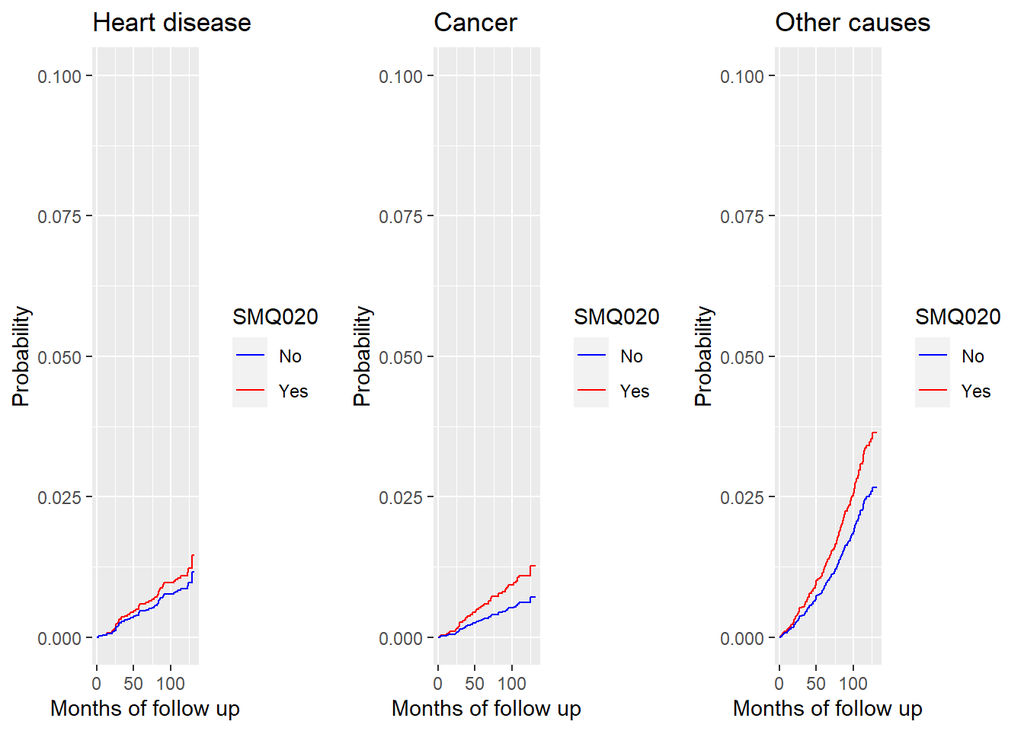

```r
### Smoking

# Compare incidence of each outcome for those who have smoked more than 100 cigarettes in life with those who haven't, both BMI 23,male, LDL 90md/dL, aged 45, systolic blood pressure 110mmHg, with no diabetes
Smoke <- data.frame(RIDAGEYR.1 = c(4.5,0,0), RIDAGEYR.2 = c(0,4.5,0), RIDAGEYR.3 = c(0,0,4.5), RIAGENDRFemale.1 = c(0,0,0), RIAGENDRFemale.2 = c(0,0,0), RIAGENDRFemale.3 = c(0,0,0), BMXBMI.1 = c(23, 0,0 ), BMXBMI.2 = c( 0,23,0 ), BMXBMI.3 = c( 0,0,23), LBDLDL.1 = c(9,0 ,0 ), LBDLDL.2 = c( 0,9,0 ), LBDLDL.3 = c( 0,0 ,9), DIQ010Borderline.1 = c(0 ,0 ,0 ), DIQ010Borderline.2 = c(0 ,0 ,0 ), DIQ010Borderline.3 = c(0 ,0 ,0 ), DIQ010Yes.1 =c(0 ,0 ,0 ), DIQ010Yes.2 = c(0 ,0 ,0 ), DIQ010Yes.3 = c(0 ,0 ,0 ), BPXSY1.1 = c(11,0,0), BPXSY1.2 =c(0,11,0), BPXSY1.3 = c(0,0,11), SMQ020Yes.1 = c(1,0,0), SMQ020Yes.2 = c(0,1,0), SMQ020Yes.3 = c(0,0,1), trans = c(1, 2, 3), strata = c(1, 2, 3))

Not_smoked  <- data.frame(RIDAGEYR.1 = c(4.5,0,0), RIDAGEYR.2 = c(0,4.5,0), RIDAGEYR.3 = c(0,0,4.5), RIAGENDRFemale.1 = c(0,0,0), RIAGENDRFemale.2 = c(0,0,0), RIAGENDRFemale.3 = c(0,0,0), BMXBMI.1 = c(23, 0,0 ), BMXBMI.2 = c( 0,23,0 ), BMXBMI.3 = c( 0,0,23), LBDLDL.1 = c(9,0 ,0 ), LBDLDL.2 = c( 0,9,0 ), LBDLDL.3 = c( 0,0 ,9), DIQ010Borderline.1 = c(0 ,0 ,0 ), DIQ010Borderline.2 = c(0 ,0 ,0 ), DIQ010Borderline.3 = c(0 ,0 ,0 ), DIQ010Yes.1 =c(0 ,0 ,0 ), DIQ010Yes.2 = c(0 ,0 ,0 ), DIQ010Yes.3 = c(0 ,0 ,0 ), BPXSY1.1 = c(11,0,0), BPXSY1.2 =c(0,11,0), BPXSY1.3 = c(0,0,11), SMQ020Yes.1 = c(0,0,0), SMQ020Yes.2 = c(0,0,0), SMQ020Yes.3 = c(0,0,0), trans = c(1, 2, 3), strata = c(1, 2, 3))


# Estimated cumulative hazards for all event times
msf.Smoke <- msfit(c1, Smoke, trans = tmat)
msf.Not_smoked <- msfit(c1, Not_smoked, trans = tmat)


# Caluculates Cumulative Incidence
pt.Smoke <- probtrans(msf.Smoke, 0)[[1]]

pt.Not_smoked <- probtrans(msf.Not_smoked, 0)[[1]]

# Plot

# Heart disease
plot21 <- ggplot(NULL, aes(x = time, y = pstate2)) +
      geom_step(data = pt.Smoke, aes(color = 'Yes')) +
      geom_step(data = pt.Not_smoked, aes(color = 'No')) + labs(title = 'Heart disease') + xlab('Months of follow up') + ylab('Probability') + ylim(0,0.1) +
scale_colour_manual(name="SMQ020",
    values=c(Yes="red", No="blue"))

# Cancer

plot22 <- ggplot(NULL, aes(x = time, y = pstate3)) +
      geom_step(data = pt.Smoke, aes(color = 'Yes')) +
      geom_step(data = pt.Not_smoked, aes(color = 'No')) + labs(title = 'Cancer') + xlab('Months of follow up') + ylab('Probability') + ylim(0,0.1) +
scale_colour_manual(name="SMQ020",
    values=c(Yes="red", No="blue"))


# Other causes

plot23 <- ggplot(NULL, aes(x = time, y = pstate4)) +
      geom_step(data = pt.Smoke, aes(color = 'Yes')) +
      geom_step(data = pt.Not_smoked, aes(color = 'No')) + labs(title = 'Other causes') + xlab('Months of follow up') + ylab('Probability') + ylim(0,0.1) +
scale_colour_manual(name="SMQ020",
    values=c(Yes="red", No="blue"))

grid.arrange(plot21, plot22, plot23, nrow=1, ncol=3)
```

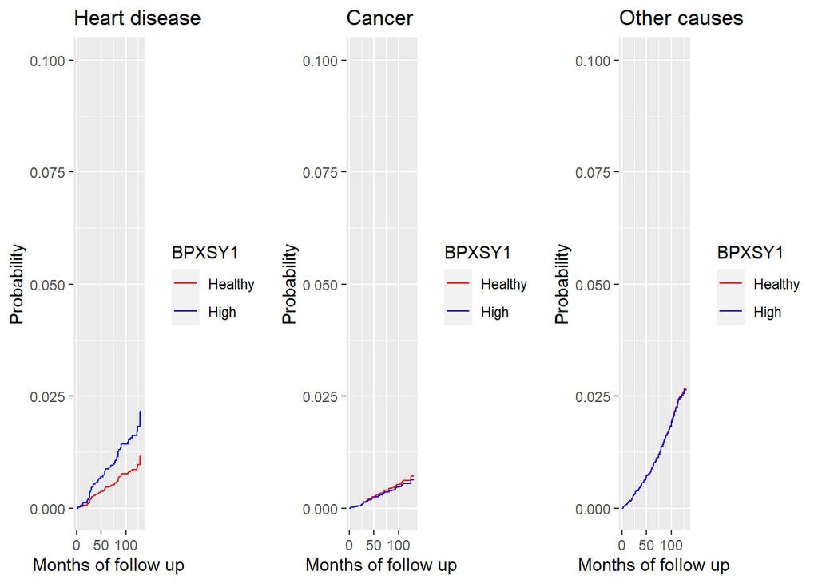

```r
### High blood pressure

# Compare incidence of each outcome for those with systolic bloof pressure 110mmHh (healthy) with 150 mmHg (high), both BMI 23, male, LDL 90md/dL, aged 45, systolic blood pressure 110mmHg, with no diabetes and not smoked more than 100 cigarettes in lifetime
Healthy <- data.frame(RIDAGEYR.1 = c(4.5,0,0), RIDAGEYR.2 = c(0,4.5,0), RIDAGEYR.3 = c(0,0,4.5), RIAGENDRFemale.1 = c(0,0,0), RIAGENDRFemale.2 = c(0,0,0), RIAGENDRFemale.3 = c(0,0,0), BMXBMI.1 = c(23, 0,0 ), BMXBMI.2 = c( 0,23,0 ), BMXBMI.3 = c( 0,0,23), LBDLDL.1 = c(9,0 ,0 ), LBDLDL.2 = c( 0,9,0 ), LBDLDL.3 = c( 0,0 ,9), DIQ010Borderline.1 = c(0 ,0 ,0 ), DIQ010Borderline.2 = c(0 ,0 ,0 ), DIQ010Borderline.3 = c(0 ,0 ,0 ), DIQ010Yes.1 =c(0 ,0 ,0 ), DIQ010Yes.2 = c(0 ,0 ,0 ), DIQ010Yes.3 = c(0 ,0 ,0 ), BPXSY1.1 = c(11,0,0), BPXSY1.2 =c(0,11,0), BPXSY1.3 = c(0,0,11), SMQ020Yes.1 = c(0,0,0), SMQ020Yes.2 = c(0,0,0), SMQ020Yes.3 = c(0,0,0), trans = c(1, 2, 3), strata = c(1, 2, 3))

High <- data.frame(RIDAGEYR.1 = c(4.5,0,0), RIDAGEYR.2 = c(0,4.5,0), RIDAGEYR.3 = c(0,0,4.5), RIAGENDRFemale.1 = c(0,0,0), RIAGENDRFemale.2 = c(0,0,0), RIAGENDRFemale.3 = c(0,0,0), BMXBMI.1 = c(23, 0,0 ), BMXBMI.2 = c( 0,23,0 ), BMXBMI.3 = c( 0,0,23), LBDLDL.1 = c(9,0 ,0 ), LBDLDL.2 = c( 0,9,0 ), LBDLDL.3 = c( 0,0 ,9), DIQ010Borderline.1 = c(0 ,0 ,0 ), DIQ010Borderline.2 = c(0 ,0 ,0 ), DIQ010Borderline.3 = c(0 ,0 ,0 ), DIQ010Yes.1 =c(0 ,0 ,0 ), DIQ010Yes.2 = c(0 ,0 ,0 ), DIQ010Yes.3 = c(0 ,0 ,0 ), BPXSY1.1 = c(15,0,0), BPXSY1.2 =c(0,15,0), BPXSY1.3 = c(0,0,15), SMQ020Yes.1 = c(0,0,0), SMQ020Yes.2 = c(0,0,0), SMQ020Yes.3 = c(0,0,0), trans = c(1, 2, 3), strata = c(1, 2, 3))


# Estimated cumulative hazards for all event times
msf.Healthy <- msfit(c1, Healthy, trans = tmat)
msf.High <- msfit(c1, High, trans = tmat)


# Caluculates Cumulative Incidence
pt.Healthy <- probtrans(msf.Healthy, 0)[[1]]

pt.High <- probtrans(msf.High, 0)[[1]]

# Plot

# Heart disease
plot31 <- ggplot(NULL, aes(x = time, y = pstate2)) +
      geom_step(data = pt.Healthy, aes(color = 'Healthy')) +
      geom_step(data = pt.High, aes(color = 'High')) + labs(title = 'Heart disease') + xlab('Months of follow up') + ylab('Probability') + ylim(0,0.1) +
scale_colour_manual(name="BPXSY1",
    values=c(Healthy="red", High="blue"))

# Cancer
plot32 <- ggplot(NULL, aes(x = time, y = pstate3)) +
      geom_step(data = pt.Healthy, aes(color = 'Healthy')) +
      geom_step(data = pt.High, aes(color = 'High')) + labs(title = 'Cancer') + xlab('Months of follow up') + ylab('Probability') + ylim(0,0.1) +
scale_colour_manual(name="BPXSY1",
    values=c(Healthy="red", High="blue"))



# Other causes
plot33 <- ggplot(NULL, aes(x = time, y = pstate4)) +
      geom_step(data = pt.Healthy, aes(color = 'Healthy')) +
      geom_step(data = pt.High, aes(color = 'High')) + labs(title = 'Other causes') + xlab('Months of follow up') + ylab('Probability') + ylim(0,0.1) +
scale_colour_manual(name="BPXSY1",
    values=c(Healthy="red", High="blue"))

grid.arrange(plot31, plot32, plot33, nrow=1, ncol=3)
```